# index

## About

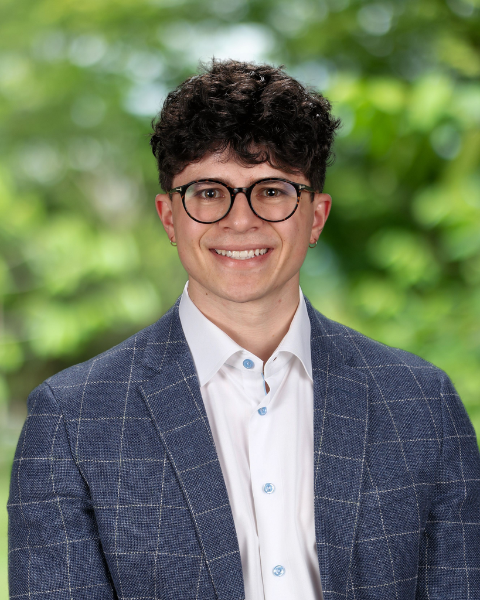

Hi! My name is Austin. I am an Equity Research Associate at [M Science](https://www.mscience.com/) covering Restaurants and AAPL. My primary focus is on DPZ, WEN, QSR, and PZZA. I currently live in the East Village in New York City. There, I spend my free time exploring local restaurants, going to the gym, and watching sports.Namely, I am a fan of the Denver Broncos, Georgetown Hoyas, and your 2023 NBA Champion Denver Nuggets. When I get the chance, I also love to ski.

[figure not shown]

I finished my latest education in May 2024, receiving a Master of Science in Data Science and Analytics from Georgetown University. In my graduate studies, I focused on Deep Learning, Large Language Models/NLP, and Network Analysis. You can read more on my coursework on the coursework page. I also completed my undergraduate studies at Georgetown, graduating in 2023 with a Bachelor of Arts in Economics and Philosophy. In undergrad, I was a four year member and director of membership for the [Georgetown University Eating Society (GUES)](https://www.gueatingsociety.com/) and [Sports Writer for The Hoya](https://thehoya.com/staff_name/austin-barish/). My sports coverage took me as far as Indianapolis for the 2021 March Madness Tournament. I remain a fan of the Georgetown Hoyas, particularly the Men’s basketball team, despite their ongoing struggles.

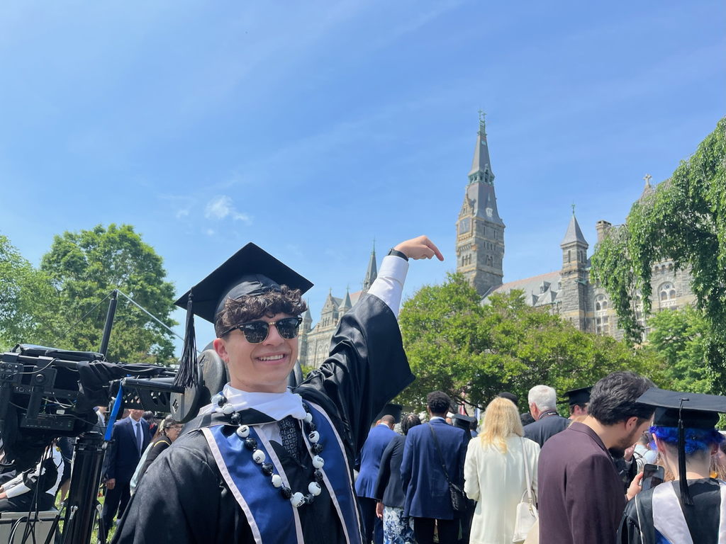

## Languages and Tools

[figure not shown]

Python

[figure not shown]

R

[figure not shown]

SQL

[figure not shown]

Stata

[figure not shown]

Tableau

[figure not shown]

Apache Spark

[figure not shown]

PyTorch

[figure not shown]

TorchVision

[figure not shown]

Keras

[figure not shown]

TensorFlow

[figure not shown]

AWS

[figure not shown]

AWS Lambda

[figure not shown]

Azure

[figure not shown]

HTML

[figure not shown]

Pandas

[figure not shown]

NetworkX

[figure not shown]

OpenCV

[figure not shown]

Scikit-Learn

[figure not shown]

Plotly

[figure not shown]

Altair

DuckDB

[figure not shown]

Polars

[figure not shown]

Ovito

[figure not shown]

ggplot

[figure not shown]

Matplotlib

## Relevant Coursework

- Fall 2019: Multivariable Calculus
- Spring 2020: Linear Algebra
- Fall 2020: Intro to Data Science and Analytics
- Spring 2021: Intro to Computer Science: Python
- Spring 2021: Economic Statistics
- Summer 2021: Data Visualization for Politics
- Fall 2021: Intro to Econometrics
- Fall 2021: Game Theory
- Fall 2022: Data Science and Analytics
- Spring 2023: Advanced Data Visualizations
- Summer 2023: Network Analytics
- Summer 2023: Image Mining and Computer Vision
- Fall 2023: Big Data and Cloud Computing
- Fall 2023: Probability Modeling and Statistic Computing
- Fall 2023: Advanced Natural Language Processing (NLP)
- Spring 2024: Statistical Learning for Data Science and Analytics
- Spring 2024: NLP with Large Language Models
- Spring 2024: Neural Networks and Deep Learning

## Contacts and Websites

- Github: https://github.com/austinbarish
- LinkedIn: https://www.linkedin.com/in/austin-barish
- Personal Email: barishaustin@gmail.com
- Phone: (720) 666-3689